# Diabetes Report

Shayan Rahim

2023-05

## Inroduction

#### [Data source](https://www.kaggle.com/datasets/houcembenmansour/predict-diabetes-based-on-diagnostic-measures)

#### According to the [CDC](https://www.cdc.gov/chronicdisease/about/index.htm#:~:text=Chronic%20diseases%20such%20as%20heart,disability%20in%20the%20United%20States.) Diabetes is one of the most common chronic diseases that people have. In this report I’m going to analyze a dataset from Kaggle which was orginally from the National Institute of Diabetes and Digestive and Kidney Diseases in Maryland. The dataset contains data fo people for who are diabetic and who aren’t. The dataset contains data for cholesterol levels, systolic and diastolic blood pressure, glucose levels, and bmi, which made me interested in the dataset. To analyze the data, I’m going to answer the question: what facors increase the likelihood of having diabetes, by anaylyzing correlations between the diagnostics that are provided in the dataset and diabetice/non-diabetic persons.

# Questions

### Main

#### What facors increase the likelihood of having diabetes?

### Other

#### Is one gender affected more than other?

#### Which ages are more affected by diabetes?

#### Do diabetics have lower or higher levels of Cholesterol?

#### How does hdl_chol of Diabetics compare to Non-Diabtics?

#### How do Cholesterol to HDL Ratios compare for diabetics and non diabetics?

#### How does Glucose compare for Diabetics and Non-Diabetics?

#### How does Systolic Blood Pressure compare for Diabetics and Non-Diabetics?

#### How does the average Daistolic Blood Pressure compare for Diabetics and Non-Diabetics?

#### Is there a correlation between BMI and Glucose?

#### What about Weight vs Glucose?

# Libaries

```r
library('dplyr', warn.conflicts = F) #for manipulating data frames
library('tidyr',warn.conflicts = F)  #for tidying up data
library('ggplot2',warn.conflicts = F) #for making graphs
library('tidyverse',warn.conflicts = F) #for transforming and presenting data
library('gridExtra', warn.conflicts = F) #for displaying tables
library('kableExtra',warn.conflicts = FALSE)
```

# Data

#### I downloaded the dataset from kaggle which came in a zip file named dibetes.zip and took out the diabetes.csv file from it and and saved it to the folder with the R Markdown file.

```r
#importing data
dbts <- read.csv("diabetes.csv")

#Let's look at the data
glimpse(dbts)
```

```
## Rows: 390
## Columns: 16
## $ patient_number  <int> 1, 2, 3, 4, 5, 6, 7, 8, 9, 10, 11, 12, 13, 14, 15, 16,…
## $ cholesterol     <int> 193, 146, 217, 226, 164, 170, 149, 164, 230, 179, 174,…
## $ glucose         <int> 77, 79, 75, 97, 91, 69, 77, 71, 112, 105, 105, 106, 99…
## $ hdl_chol        <int> 49, 41, 54, 70, 67, 64, 49, 63, 64, 60, 117, 63, 34, 7…
## $ chol_hdl_ratio  <chr> "3,9", "3,6", "4", "3,2", "2,4", "2,7", "3", "2,6", "3…
## $ age             <int> 19, 19, 20, 20, 20, 20, 20, 20, 20, 20, 20, 20, 21, 21…
## $ gender          <chr> "female", "female", "female", "female", "female", "fem…
## $ height          <int> 61, 60, 67, 64, 70, 64, 62, 72, 67, 58, 70, 68, 65, 63…
## $ weight          <int> 119, 135, 187, 114, 141, 161, 115, 145, 159, 170, 187,…
## $ bmi             <chr> "22,5", "26,4", "29,3", "19,6", "20,2", "27,6", "21", …
## $ systolic_bp     <int> 118, 108, 110, 122, 122, 108, 105, 108, 100, 140, 132,…
## $ diastolic_bp    <int> 70, 58, 72, 64, 86, 70, 82, 78, 90, 100, 86, 110, 62, …
## $ waist           <int> 32, 33, 40, 31, 32, 37, 31, 29, 31, 34, 37, 49, 39, 28…
## $ hip             <int> 38, 40, 45, 39, 39, 40, 37, 36, 39, 46, 41, 58, 43, 39…
## $ waist_hip_ratio <chr> "0,84", "0,83", "0,89", "0,79", "0,82", "0,93", "0,84"…
## $ diabetes        <chr> "No diabetes", "No diabetes", "No diabetes", "No diabe…
```

# Data variables

##### **patient_number**: ID of the patient

##### **cholesterol**: levels of cholesterol in blood in

##### **glucose**: levels of glucose concentration in blood

##### **hdl_chol**: level of high-density lipoprotein cholesterol

##### **chol_hdl_ratio**: ratio of cholesterol levels to high-density lipoprotein cholesterol levels

##### **age**: age of patient

##### **gender**: gender of patient

##### **height**: height in inches

##### **weight**: weight in pounds

##### **bmi**: body mass index

##### **systolic_bp**: measure of pressure in arteries when heart beats

##### **diastolic_bp**: measure of pressure in arteries when heart rests between beats

##### **waist**: measure of waist in inches

##### **hip**: measure of hip in inches

##### **waist_hip_ratio**: ratio of waist to hip

##### **diabetes**: whether patient has diabetes or not

# Is one gender affected more than other?

#### I wanted to first look at the number of people who were diabetic or not diabetic by gender. I did this by plotting the data by grouping by the gender and diabetes variabes and then counting the number of people who are and aren’t diabetic in the dataset.

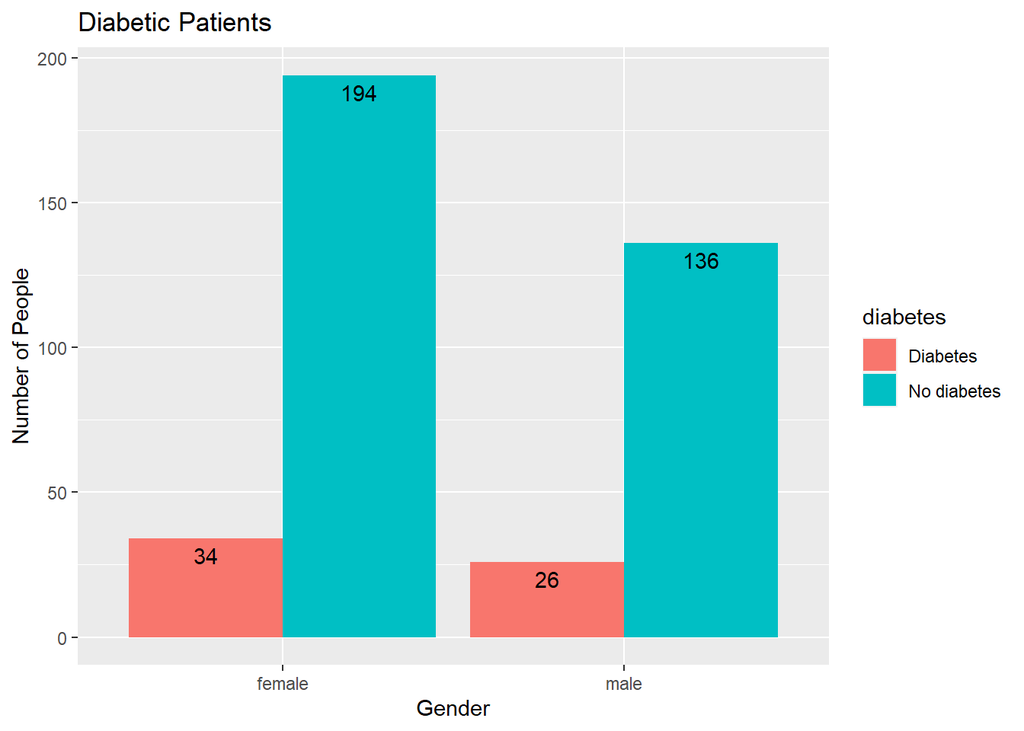

[output not shown]

#### This table shows the precent of males and females who have diabetese

# Which ages are more affected by diabetes?

#### I then wanted to look at the data and see how age affects a person having diabetes. I did this by grouping the data by age diabetes variables and then plotted them into a columns charts

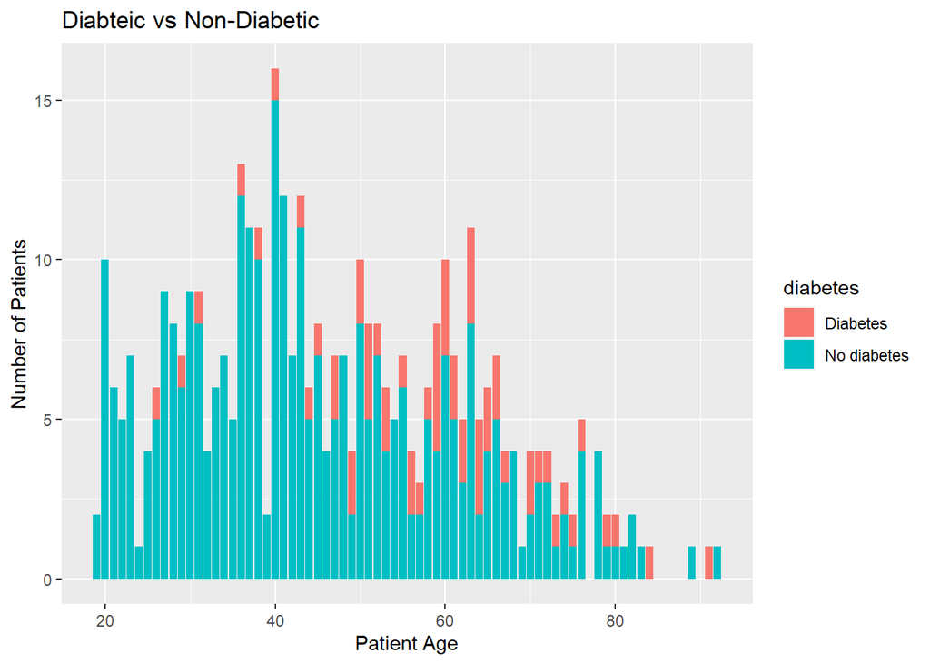

#### It looks like as the population gets older, the proportion of people having diabetes is increasing. It starts to increase especially around the age of 50.

# Do diabetics have lower or higher levels of Cholesterol?

#### Here I wanted to see whether diabetic persons had lower or higher levels of cholesterol compared to non-diabetics and if there’s a correlation between age and cholesterol levels. I did this by grouping by cholesterol and age variabes and then plotting the data by using geom_point, geom_smooth to see the moving average, and facet wrap to seperate diabetics from non-diabetics.

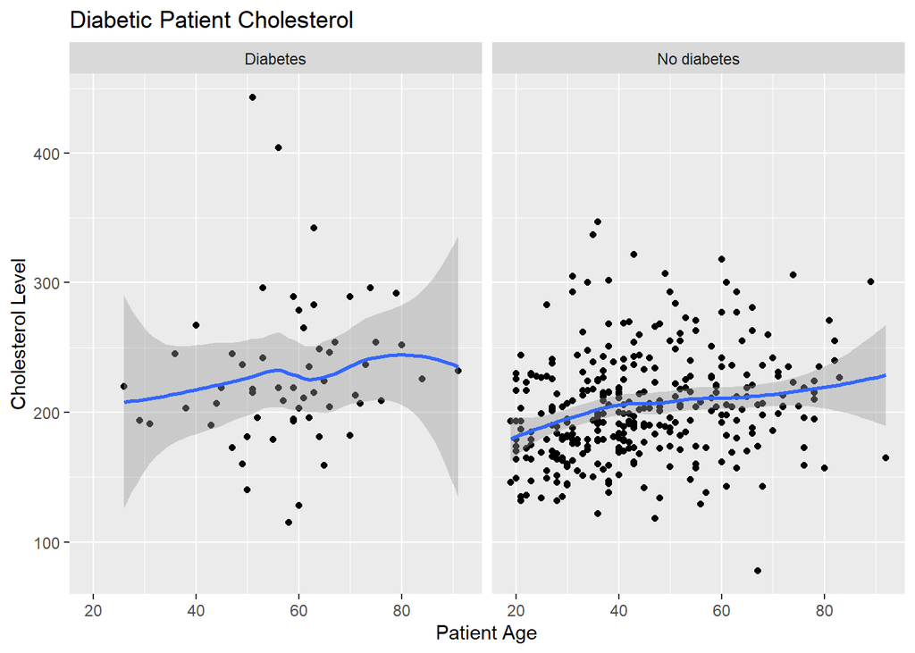

#### As you can see, it looks like diabetics have, on average, higher levels of cholesterol. And as the age of the person increases, there cholesterol level are also likely to increase. I also made a table show the actual average cholesterol levels for diabetic and non diabetic, as you can see below.

| average_diabetic_cholesterol | average_non_diabetic_cholesterol |
| --- | --- |
| 228.6 | 203.3455 |

# How does hdl_chol of Diabetics compare to Non-Diabtics?

#### Then I wanted to compare the levels of HDL Cholesterol between diabetic and non diabetic. HDL (high-density lipoprotein) Cholesterol according to the CDC is considered to be a “good” cholesterol, and having high levels of it is good, because HDL carries Cholesterol to the liver to get rid of, and higher levels of HDL Cholesterol means lower levels of Cholesterol.

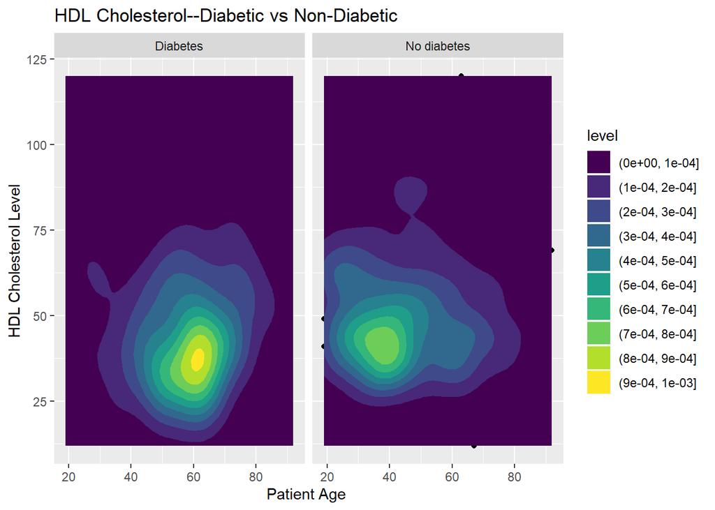

#### The graph clearly shows that people with Diabetes have lower levels of HDL Cholesterol, meaning they have higher levels of Cholesterol, which is confirmed by the CHolesterol to HDL Raios graph shown bloew . I also wanted to know the actual averages, so I made a table also showing them below.

| average_diabetic_hdl_cholesterol | average_non_diabetic_hdl_cholesterol |
| --- | --- |
| 45.28333 | 51.17273 |

# Cholesterol to HDL Ratio

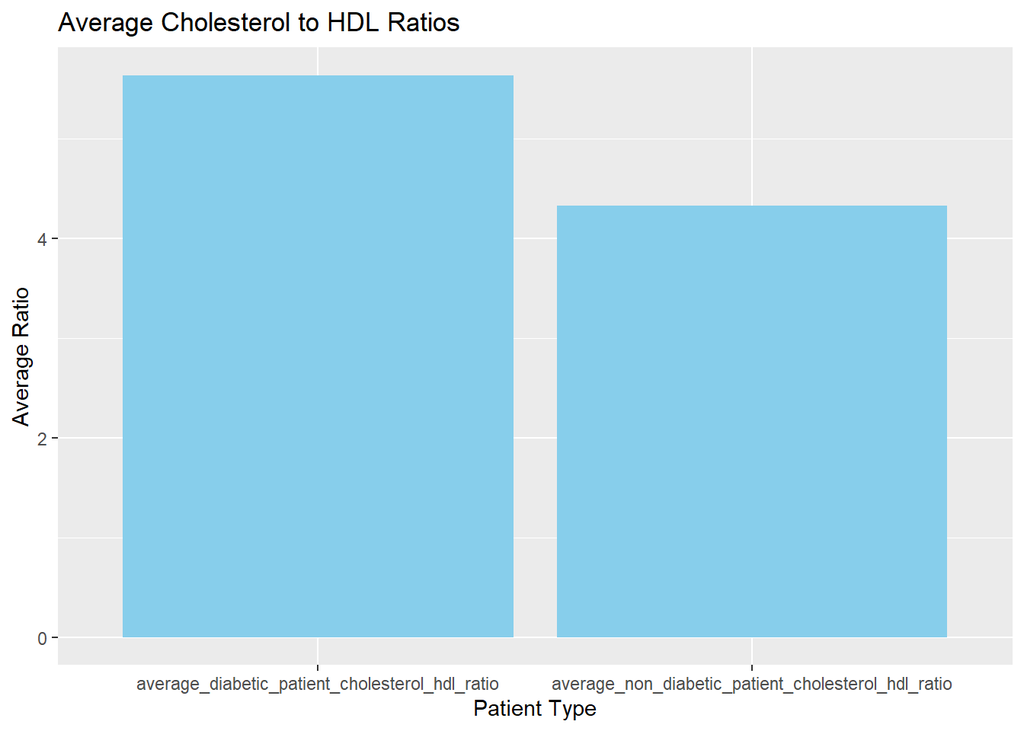

# How does Glucose compare for Diabetics and Non-Diabetics?

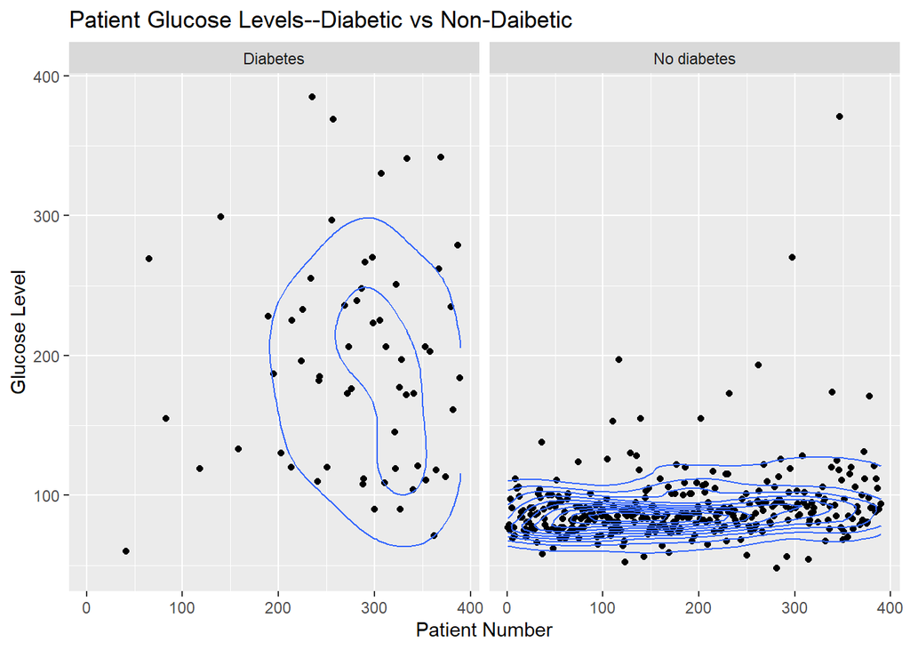

#### Here we can see that glucose levels are significantly higher for people with diabetes compared to non-diabetics. We can conclude from this that glucuse plays a significant role in determining whether a peron has diabetes or not.

#### This table shows the actual averages for glucoses levels in diabetics and non-diabetics.

| average_diabetic_patient_glucose_level | average_non_diabetic_patient_glucose_level |
| --- | --- |
| 194.1667 | 91.55152 |

# How does Systolic Blood Pressure compare for Diabetics and Non-Diabetics?

#### Here I wanted to compare Systolic Blood Pressure between Diabetics and Non-Diabetics as they aged. Accoring to the [CDC](https://www.cdc.gov/bloodpressure/about.htm#:~:text=The%20first%20number%2C%20called%20systolic,your%20heart%20rests%20between%20beats.)measures the pressure in your arteries when your heart beats.

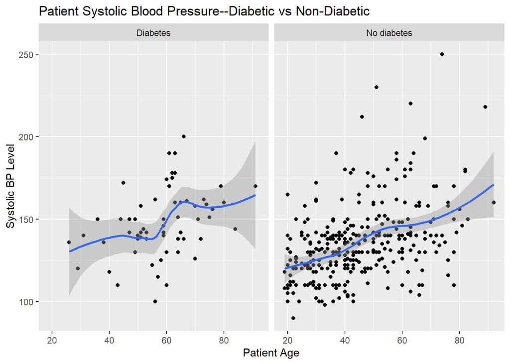

#### Here we can see that the moving average of Systolic Blood increases as people age, but sits a little higher for people who are diabetic, showing a correlation between being diabetic and having a high systolic bp. The table below confirms this statement by showing the average systolic bp for diabetics and non-diabetics

| average_diabetic_patient_systolic_level | average_non_diabetic_patient_systolic_level |
| --- | --- |
| 147.7667 | 135.2 |

# How does the average Daistolic Blood Pressure compare for Diabetics and Non-Diabetics?

#### According to the [CDC](https://www.cdc.gov/bloodpressure/about.htm#:~:text=The%20first%20number%2C%20called%20systolic,your%20heart%20rests%20between%20beats.), measures the pressure in your arteries when your heart rests between beats. And this graph shows the average diastolic bp comapared to diabetic and non-diabetic.

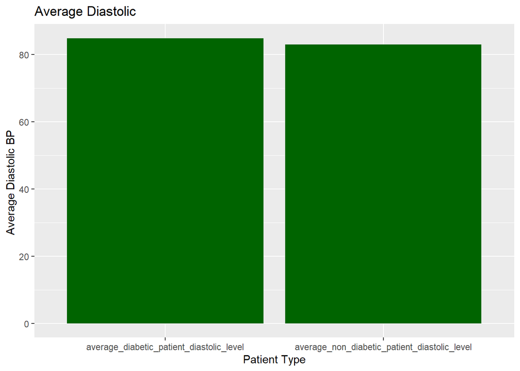

#### Here we don’t see much diffrence between the averages for the two groups, which means that diastolic bp isn’t correlated with a person being diabetics

# Is there a correlation between BMI and Glucose?

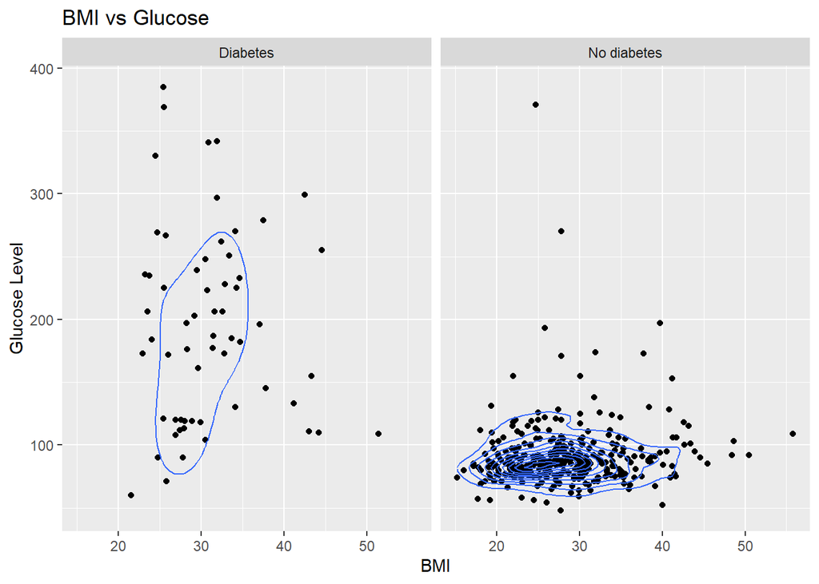

# What about Weight vs Glucose?

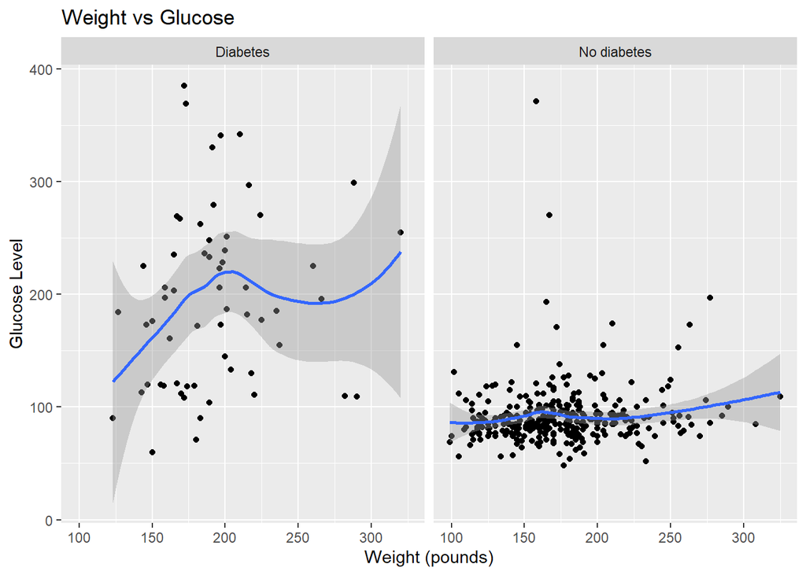

#### This graph shows that as diabetic people gain more weight, on average, their glucose levels rise faster than those who are not diabetic.

# Average Weight

#### Below, a table and a graph show the average weight of diabetic and non diabetic people.

| average_diabetic_weight | average_non_diabetic_weight |
| --- | --- |
| 192.8333 | 174.603 |

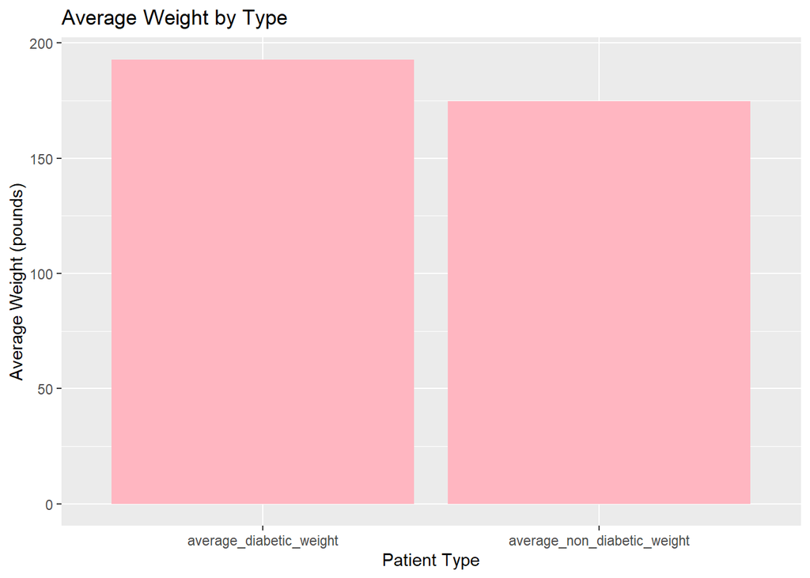

#### These show that diabetic people weigh more on average than non-diabetic people, linking a higher a weight to diabetes.

# Summary